# Functions

# 1 Functions

The most important thing to understand about R is that functions are objects in their own right, a language property often called “first-class functions”. You can work with them exactly the same way you work with any other type of object.

## 1.1 Function components

All R functions have three parts:

- The `formals()`, the list of arguments that control how you call the function.
- The `body()`, the code inside the function.
- The `environment()`, which determines how the function finds values associated with names.

When you print a function in R, it shows you these three important components. If the environment isn’t displayed, it means that the function was created in the global environment.

```r
f <- function(x) {
    # A comment
    x^2
}
f
```

```
## function(x) {
##     # A comment
##     x^2
## }
```

```r
formals(f)
```

```r
body(f)
```

```
## {
##     x^2
## }
```

```r
environment(f)
```

```
## <environment: R_GlobalEnv>
```

Like all objects in R, functions can also possess any number of additional `attributes()`. One attribute used by base R is “srcref”, short for source reference, which points to the source code used to create the function. Unlike `body()`, this contains code comments and other formatting. You can also add attributes to a function. For example, you can set the `class()` and add a custom `print()` method.

```r
attributes(f)
```

```
## $srcref
## function(x) {
##     # A comment
##     x^2
## }
```

The assignment forms of `body()`, `formals()`, and `environment()` can also be used to modify functions.

```r
formals(f) <- alist(x = , y = 5 * 2)  # alist allows tags without values. Values are not evaluated
f
```

```
## function (x, y = 5 * 2)
## {
##     x^2
## }
```

```r
body(f) <- expression(x^3 + y)
f
```

```
## function (x, y = 5 * 2)
## x^3 + y
```

```r
f(2)
```

```
## [1] 18
```

### 1.1.1 Primitive functions

There is one exception to the rule that functions have three components. Primitive functions, like `sum()`, call C code directly with `.Primitive()` and contain no R code. Therefore their `formals()`, `body()`, and `environment()` are all `NULL`:

```r
sum
```

```
## function (..., na.rm = FALSE)  .Primitive("sum")
```

```r
formals(sum)
```

```r
body(sum)
```

```r
environment(sum)
```

Primitive functions are only found in the base package. The chief advantage of primitive functions is that they can truly modify objects in place

### 1.1.2 Exercises

1. What function allows you to tell if an object is a function? What function allows you to tell if a function is a primitive function?  
   **A**:

   ```r
   f <- function(x) x^2
   is.function(f)
   is.function(sum)
   is.primitive(f)
   is.primitive(sum)
   ```

   ```
   ## [1] TRUE
   ## [1] TRUE
   ## [1] FALSE
   ## [1] TRUE
   ```

2. This code makes a list of all functions in the base package. Use it to answer the following questions:

   ```r
   objs <- mget(ls("package:base"), inherits = TRUE)
   funs <- Filter(is.function, objs)
   ```

   Which base function has the most arguments?

   ```r
   f_arg_length <- funs %>% map_int(~length(formals(.)))
   f_arg_length[which.max(f_arg_length)]
   ```

   ```
   ## scan
   ##   22
   ```

   How many base functions have no arguments? What’s special about those functions?

   ```r
   # functions without arguments
   f_arg_length <- funs %>% map_int(~length(formals(.)))
   f_arg_length[which.max(f_arg_length)]
   ```

   ```
   ## scan
   ##   22
   ```

   ```r
   sum(f_arg_length == 0)
   ```

   ```
   ## [1] 224
   ```

   ```r
   # all primitive functions return NULL for formals, but so do other functions
   # with no arguments
   f_arg_NULL <- funs %>% map_lgl(~is.null(formals(.)))
   sum(f_arg_NULL)
   ```

   ```
   ## [1] 224
   ```

   ```r
   f_arg_0 <- funs %>% map_lgl(~!is.null(formals(.)) && length(formals(.)) == 0)
   sum(f_arg_0)  #0 - non-primitive functions with no arguments return NULL for a formal
   ```

   ```
   ## [1] 0
   ```

   ```r
   f_arg_primitve <- funs %>% map_lgl(~is.primitive(.))
   sum(f_arg_primitve)  # number of primitive functions
   ```

   ```
   ## [1] 183
   ```

   ```r
   f_arg_NULL_not_primitive <- funs %>% map_lgl(~is.null(formals(.)) && !is.primitive(.))
   sum(f_arg_NULL_not_primitive)  # number of non-primitive functions with no arguments
   ```

   ```
   ## [1] 41
   ```

   ```r
   # non-primitve functions with no arguments
   str(funs[which(f_arg_NULL_not_primitive)])
   ```

   ```
   ## List of 41
   ##  $ closeAllConnections     :function ()
   ##  $ contributors            :function ()
   ##  $ Cstack_info             :function ()
   ##  $ date                    :function ()
   ##  $ default.stringsAsFactors:function ()
   ##  $ extSoftVersion          :function ()
   ##  $ getAllConnections       :function ()
   ##  $ geterrmessage           :function ()
   ##  $ getLoadedDLLs           :function ()
   ##  $ getRversion             :function ()
   ##  $ getTaskCallbackNames    :function ()
   ##  $ getwd                   :function ()
   ##  $ iconvlist               :function ()
   ##  $ is.R                    :function ()
   ```

   [output cut: 27 more lines]

   How could you adapt the code to find all primitive functions?

   ```r
   objs <- mget(ls("package:base"), inherits = TRUE)
   funs <- Filter(is.primitive, objs)
   length(funs)
   ```

   ```
   ## [1] 183
   ```

3. What are the three important components of a function?  
   **A**: The `formals()`, `body()` and `environment()`.
4. When does printing a function not show what environment it was created in?  
   **A**: When the function was created in the global environment.

## 1.2 Lexical scoping

In Names and values, we discussed assignment, the act of binding a name to a value. Scoping works in the opposite direction: how do you find the value associated with a given name in a given context?

For example, what will the following code return, 10 or 20?

```r
x <- 10
f <- function() {
    x <- 20
    x
}

f()
```

```
## [1] 20
```

There are four primary rules that define R’s lexical scoping:

- Name masking
- Functions vs. variables
- A fresh start
- Dynamic lookup

### 1.2.1 Name masking

The following example illustrates the most basic principle of lexical scoping: names in defined inside a function override names defined outside of it.

```r
x <- 10
y <- 20
f <- function() {
    x <- 1
    y <- 2
    c(x, y)
}
f()
```

```
## [1] 1 2
```

If a name isn’t defined inside a function, R will look one level up.

```r
x <- 2
g <- function() {
    y <- 1
    c(x, y)
}
g()
```

```
## [1] 2 1
```

The same rules apply if a function is defined inside another function: look inside the current function, then where that function was defined, and so on, all the way up to the global environment, and then on to other loaded packages.

```r
x <- 1
h <- function() {
    y <- 2
    i <- function() {
        z <- 3
        c(x, y, z)
    }
    i()
}
h()
```

```
## [1] 1 2 3
```

The same rules apply to closures, functions created by other functions. The following function, `j()`, returns a function.

```r
j <- function(x) {
    y <- 2
    function() {
        c(x, y)
    }
}
k <- j(1)
k()
```

```
## [1] 1 2
```

This seems a little magical: how does R know what the value of `y`is after `j()` has returned? It works because `k` preserves the environment in which it was defined and because the environment includes the value of `y`.

### 1.2.2 Functions vs. variables

The same principles apply regardless of the type of associated value — functions are found in the same way as variables:

```r
l <- function(x) x + 1
m <- function() {
    l <- function(x) x * 2
    l(10)
}
m()
```

```
## [1] 20
```

There is one small tweak to the rule for functions. If you are using a name in a context where it’s obvious that you want a function (e.g., f(3)), R will ignore objects that are not functions while it is searching. In the following example n takes on a different value depending on whether R is looking for a function or a variable.

```r
n <- function(x) x/2
o <- function() {
    n <- 10
    n(n)
}
o()
```

```
## [1] 5
```

However, using the same name for functions and other objects will make for confusing code, and is best avoided.

### 1.2.3 A fresh start

What happens to the values in between invocations of a function?

```r
j <- function() {
    if (!exists("a")) {
        a <- 1
    } else {
        a <- a + 1
    }
    a
}

j()
```

```
## [1] 1
```

```r
j()
```

```
## [1] 1
```

`j()` returns the same value, 1, every time it is called. This is because every time a function is called, a new environment is created to host its execution. A function has no way to tell what happened the last time it was run; each invocation is completely independent. (We’ll see some ways to get around this in mutable state.)

### 1.2.4 Dynamic lookup

Lexical scoping determines where to look for values, not when to look for them. R looks for values when the function is run, not when it’s created. This means that the output of a function can be different depending on objects outside its environment:

```r
f <- function() x
x <- 15
f()
```

```
## [1] 15
```

```r
x <- 20
f()
```

```
## [1] 20
```

This behaviour can be quite annoying. If you make a spelling mistake in your code, you won’t get an error when you create the function, and you might not even get one when you run the function, depending on what variables are defined in the global environment.

One way to detect this problem is to use `codetools::findGlobals()`. This function lists all the external dependencies (unbound symbols) within a function:

```r
f <- function() x + 1
codetools::findGlobals(f)
```

```
## [1] "+" "x"
```

Another way to try and solve the problem would be to manually change the environment of the function to the `emptyenv()`, an environment which contains nothing:

```r
environment(f) <- emptyenv()
f()
```

```
## Error in x + 1: could not find function "+"
```

Both of these approaches reveal why this undesirable behaviour exists: R relies on lexical scoping to find everything, even the `+` operator.

### 1.2.5 Exercises

1. What does the following code return? Why? What does each of the three `c`s mean?  
   **A**:

   ```r
   c <- 10
   c(c = c)
   ```

   ```
   ##  c
   ## 10
   ```

   Same as:

   ```r
   a <- 10
   c(b = a)
   ```

   ```
   ##  b
   ## 10
   ```

   Note these below:

   ```r
   a <- NULL
   f <- function(a) 3
   f(a <- 1)  # not guaranteed to evaluate because of lazy evaluation
   a  # a is still NULL
   f(a = 1)  # this is a inside the function
   a  # a is still NULL
   ```

   ```
   ## [1] 3
   ## NULL
   ## [1] 3
   ## NULL
   ```

   ```r
   a <- NULL
   f <- function(a) a + 1
   f(a <- 1)  # evaluates because a argument of function is evaluated in the function
   a  # a is 1
   f(a = 2)  # returns 3
   a  # a is still 1
   ```

   ```
   ## [1] 2
   ## [1] 1
   ## [1] 3
   ## [1] 1
   ```

   ```r
   a <- NULL
   f <- function(a) a
   f(a <- 1)  # does not display return value
   withVisible(f(a <- 1))$visible
   a  # 1
   ```

   ```
   ## [1] FALSE
   ## [1] 1
   ```

   ```r
   a <- NULL
   f <- function(a) (a)
   f(a <- 1)  # return value is displayed
   a  # 1
   ```

   ```
   ## [1] 1
   ## [1] 1
   ```

   ```r
   a <- NULL
   f <- function(a) a
   f((a <- 1))  # return value is displayed
   a  # 1
   ```

   ```
   ## [1] 1
   ## [1] 1
   ```

   ```r
   a <- NULL
   f <- function(a) a
   f((a = 1))  # same as f(a <- 1) but with return value displayed
   a  # 1
   ```

   ```
   ## [1] 1
   ## [1] 1
   ```

   ```r
   # normal usage
   a <- NULL
   f <- function(a) a
   f(a = 1)
   a  #NULL
   ```

   ```
   ## [1] 1
   ## NULL
   ```

   ```r
   a <- NULL
   f <- function(a) a
   f(a = a <- 1)  # does not display return value
   a  #1
   ```

   ```
   ## [1] 1
   ```

2. What are the four principles that govern how R looks for values?  
   **A**: name masking, functions vs. variables. a fresh start, dynamic lookup
3. What does the following function return?

   ```r
   f <- function(x) {
       f <- function(x) {
           f <- function(x) {
               x^2
           }
           f(x) + 1
       }
       f(x) * 2
   }
   f(10)
   ```

   ```
   ## [1] 202
   ```

## 1.3 Lazy evaluation

In R, function arguments are lazily evaluated, which means that they’re only evaluated if they’re accessed. For example, this code doesn’t generate an error because x is never used:

```r
f <- function(x) {
    10
}
f(stop("This is an error!"))
```

```
## [1] 10
```

One place that this laziness is useful is in if statements. For example, in the code block below, the second competent of the `if` statement `(x > 0)` will only be evaluated if the first `(!is.null(x))` is true. If it wasn’t, the statement would return an error because `NULL > 0` is a logical vector of length 0 and not a valid input to if.

```r
x <- NULL
if (!is.null(x) && x > 0) {

}
```

### 1.3.1 Forcing evaluation

If you want to ensure that an argument is eagerly evaluated, use `force()`:

```r
f <- function(x) {
    force(x)
    10
}
f(stop("This is an error!"))
```

```
## Error in force(x): This is an error!
```

The definition of `force()` is simple:

```r
force
```

```
## function (x)
## x
## <bytecode: 0x0000000005d816c8>
## <environment: namespace:base>
```

However, it’s better to use `force(x)` than just `x`, even though they do the same thing: `force()` provides a clear signal that you’re deliberately forcing evaluation.

```r
g <- function(x) {
    function() {
        x
    }
}
```

There’s a subtle bug in the definition of this function: the value of `x` is captured not when you call `g()`, but when you call the function that `g()` returns:

```r
x <- 10
g1 <- g(x)

x <- 20
g1()
```

```
## [1] 20
```

And even more confusingly this only happens once. Once you have called the function returned by `g()`, the value is locked in:

```r
x <- 30
g1()
```

```
## [1] 20
```

We can avoid this problem by forcing `x`:

```r
g <- function(x) {
    force(x)

    function() {
        x
    }
}

x <- 10
g1 <- g(x)

x <- 20
g1()
```

```
## [1] 10
```

### 1.3.2 Promises

Lazy evaluation is powered by a data structure called a promise, or (less commonly) a thunk. A promise has two components:

- The expression, like `x + y` which gives rise to the delayed computation.
- The environment where the expression should be evaluated.

The first time a promise is accessed the expression is evaluated in the environment where it was created. This value is cached, so that subsequent access to the evaluated promise does not recompute the value. The following code only computes `runif(1)` once:

```r
j <- function(x) {
    c(x, x, x)
}

j(runif(1))
```

```
## [1] 0.469848 0.469848 0.469848
```

You can also create promises “by hand” using `delayedAssign()`:

```r
delayedAssign("x", {
    print("Executing code")
    runif(1)
})
x
```

```
## [1] "Executing code"
```

```
## [1] 0.8759896
```

```r
x
```

```
## [1] 0.8759896
```

### 1.3.3 Default arguments

Thanks to lazy evaluation, defaults value can be defined in terms of other arguments, or even in terms of variables defined later in the function:

```r
g <- function(x = 1, y = x * 2, z = a + b) {
    a <- 10
    b <- 100

    c(x, y, z)
}

g()
```

```
## [1]   1   2 110
```

Not usually recommend because it makes requires that you know exactly *when* default arguments are evaluated in order to predict *what* they will evaluate to.

The evaluation environment is slightly different for default and user supplied arguments, as default arguments are evaluated inside the function. This means that seemingly identical calls can yield different results. It’s easiest to see this with an extreme example:

```r
f <- function(x = ls()) {
    a <- 1
    x
}

# ls() evaluated inside f:
f()
```

```
## [1] "a" "x"
```

```r
# ls() evaluated in global environment:
f(ls())
```

```
##  [1] "a"                        "c"
##  [3] "f"                        "f_arg_0"
##  [5] "f_arg_length"             "f_arg_NULL"
##  [7] "f_arg_NULL_not_primitive" "f_arg_primitve"
##  [9] "funs"                     "g"
## [11] "g1"                       "h"
## [13] "j"                        "k"
## [15] "l"                        "m"
## [17] "n"                        "o"
## [19] "objs"                     "x"
## [21] "y"
```

### 1.3.4 Missing arguments

If an argument has a default, you can determine if the value comes from the user or the default with `missing()`:

```r
i <- function(x = 10) {
    list(missing(x), x)
}
str(i())
```

```
## List of 2
##  $ : logi TRUE
##  $ : num 10
```

```r
str(i(10))
```

```
## List of 2
##  $ : logi FALSE
##  $ : num 10
```

A problem with missing arguments is that when you look at the function definition, there’s no way to tell that z is optional.

```r
my_fun <- function(x, y, z) {
    if (missing(z)) {
        z <- default_z(x, y)
    }
}
```

Better to use a default value of `NULL`.

```r
my_fun <- function(x, y, z = NULL) {
    if (is.null(z)) {
        z <- default_z(x, y)
    }
}
```

### 1.3.5 Exercises

1. What does this function return? Why? Which principle does it illustrate?

   ```r
   y <- 10
   f <- function(x = {y <- 1; 2}, y = 0) {
     x + y
   }
   f() #3
   ```

   ```
   ## [1] 3
   ```

   ```r
   y # 10
   ```

   ```
   ## [1] 10
   ```

   **A**: the default values for `x` and `y` are evaluated inside the function. The evaluation of `x` leads to `y`, inside the function, being assigned `1`; `x` is assigned `2`. Illustrates lazy evaluation. Note:

   ```r
   f <- function(x = y <- {print("y1"); 1}, y = {print("y2"); 2}) {
     x + y
   }
   f() # 2: prints y1
   ```

   ```
   ## [1] "y1"
   ```

   ```
   ## [1] 2
   ```

   ```r
   # it appears that the 2nd function argument marks y as a promise,
   # then y is evaluated as part of the evaluation of x
   # and is cached, and that value used when y is added to x
   ```

   ```r
   f <- function(x = y <- {print("y1"); 1}, y = {print("y2"); 2}) {
     y + x
   }
   f() # 3: prints y2 and then y1
   ```

   ```
   ## [1] "y2"
   ## [1] "y1"
   ```

   ```
   ## [1] 3
   ```

2. What does this function return? Why? Which principle does it illustrate?

   ```r
   f <- function(x = z) {
       z <- 100
       x
   }
   f()
   ```

   ```
   ## [1] 100
   ```

   **A**: it returns `100` and illustrates lazy evaluation.
3. In `hist()`, the default value of `xlim` is `range(breaks)`, the default value for breaks is `"Sturges"`, and

   ```r
   range("Sturges")
   ```

   ```
   ## [1] "Sturges" "Sturges"
   ```

   Explain how `hist()` works to get a correct xlim value.  
   **A**: `range(breaks)` is evaluated lazily.
4. Explain why this function works. Why is it confusing?

   ```r
   show_time <- function(x = stop("Error!")) {
       stop <- function(...) Sys.time()
       print(x)
   }
   show_time()
   ```

   ```
   ## [1] "2018-06-30 21:39:06 -05"
   ```

   **A**: `x` is not evaluated until `print(x)`, at which point the function `stop()` has been reassigned to `Sys.time()`.

## 1.4 `...` (dot-dot-dot)

Functions can have a special argument `...`. If a function has this argument, it can take any number of additional arguments.

Inside a function, you can use `...` to pass those additional arguments on to another function:

```r
f <- function(x, ...) {
    g(...)
}

g <- function(y, z) {
    list(y = y, z = z)
}

str(f(x = 1, y = 2, z = 3))
```

```
## List of 2
##  $ y: num 2
##  $ z: num 3
```

it’s possible (but rarely useful) to refer to elements of `...` by their position, using a special form:

```r
f <- function(...) {
    list(first = ..1, third = ..3)
}
str(f(1, 2, 3))
```

```
## List of 2
##  $ first: num 1
##  $ third: num 3
```

More often useful is `list(...)`, which evaluates the arguments are stores in a list:

```r
f <- function(...) {
    list(...)
}
str(f(a = 1, b = 2))
```

```
## List of 2
##  $ a: num 1
##  $ b: num 2
```

Named arguments passed in `...` can be referred to by name.

```r
g <- function(...) {
    f <- function(..., x = 0) {
        c(x, ...)
    }
    f(...)
}
g(x = 1, 2, 3)  # returns 1, 2, 3
```

```
## [1] 1 2 3
```

```r
g(1, 2, 3)  # returns 0, 1, 2, 3
```

```
## [1] 0 1 2 3
```

There are two primary uses of `...`, both of which we’ll come back to later in the book:

- If your function takes a function as an argument, you want some way to pass on additional arguments to that function.
- If your function is an S3 generic, you need some way to allow methods to take arbitrary extra arguments.

Using `...` comes with two downsides:

- When you use it to pass arguments on to another function, you have to carefully explain to the user where those arguments go.
- Any misspelled arguments will not raise an error. This makes it easy for typos to go unnoticed:

  ```r
  sum
  ```

  ```
  ## function (..., na.rm = FALSE)  .Primitive("sum")
  ```

  ```r
  sum(1, 2, NA, na_rm = TRUE)
  ```

  ```
  ## [1] NA
  ```

### 1.4.1 Exercises

1. Explain the following results:

   ```r
   sum(1, 2, 3)
   ```

   ```
   ## [1] 6
   ```

   ```r
   mean(1, 2, 3)
   ```

   ```
   ## [1] 1
   ```

   ```r
   sum(1, 2, 3, na.omit = TRUE)
   ```

   ```
   ## [1] 7
   ```

   ```r
   mean(1, 2, 3, na.omit = TRUE)
   ```

   ```
   ## [1] 1
   ```

   **A** : `sum()` is a primitve function which just takes `...` as an argument. `mean()` is a S3 generic that takes an object as the first argument.

   ```r
   sum
   ```

   ```
   ## function (..., na.rm = FALSE)  .Primitive("sum")
   ```

   ```r
   mean
   ```

   ```
   ## function (x, ...)
   ## UseMethod("mean")
   ## <bytecode: 0x0000000019723ad8>
   ## <environment: namespace:base>
   ```

   ```r
   methods(mean)  # first argument of mean(1, 2, 3) is a double - hence mean.default is used
   ```

   ```
   ## [1] mean.Date     mean.default  mean.difftime mean.POSIXct  mean.POSIXlt
   ## see '?methods' for accessing help and source code
   ```

   ```r
   mean(c(1, 2, 3))
   ```

   ```
   ## [1] 2
   ```

   `na.omit = TRUE` in `sum()` evaluates to `1`.
2. In the following call, explain how to find the documentation for the named arguments in the following function call:

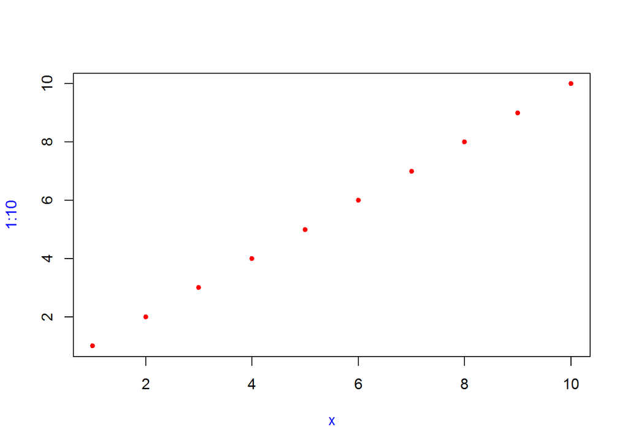

   ```r
   plot(1:10, col = "red", pch = 20, xlab = "x", col.lab = "blue")
   ```

   **A**:

   ```r
   plot
   ```

   ```
   ## function (x, y, ...)
   ## UseMethod("plot")
   ## <bytecode: 0x00000000142d0798>
   ## <environment: namespace:graphics>
   ```

   ```r
   methods(plot)
   ```

   ```
   ##  [1] plot,ANY-method        plot,color-method      plot.acf*
   ##  [4] plot.ACF*              plot.augPred*          plot.compareFits*
   ##  [7] plot.data.frame*       plot.decomposed.ts*    plot.default
   ## [10] plot.dendrogram*       plot.density*          plot.ecdf
   ## [13] plot.factor*           plot.formula*          plot.function
   ## [16] plot.ggplot*           plot.gls*              plot.gtable*
   ## [19] plot.hclust*           plot.histogram*        plot.HoltWinters*
   ## [22] plot.intervals.lmList* plot.irt*              plot.isoreg*
   ## [25] plot.lm*               plot.lme*              plot.lmList*
   ## [28] plot.medpolish*        plot.mlm*              plot.nffGroupedData*
   ## [31] plot.nfnGroupedData*   plot.nls*              plot.nmGroupedData*
   ## [34] plot.pdMat*            plot.poly*             plot.poly.parallel*
   ## [37] plot.ppr*              plot.prcomp*           plot.princomp*
   ## [40] plot.profile.nls*      plot.psych*            plot.R6*
   ## [43] plot.ranef.lme*        plot.ranef.lmList*     plot.raster*
   ## [46] plot.residuals*        plot.shingle*          plot.simulate.lme*
   ## [49] plot.spec*             plot.stepfun           plot.stl*
   ## [52] plot.table*            plot.trellis*          plot.ts
   ## [55] plot.tskernel*         plot.TukeyHSD*         plot.Variogram*
   ## see '?methods' for accessing help and source code
   ```

   ```r
   `?`(plot.default)
   ```

3. Why does `plot(1:10, col = "red")` only colour the points, not the axes or labels? Read the source code of `plot.default()` to find out.

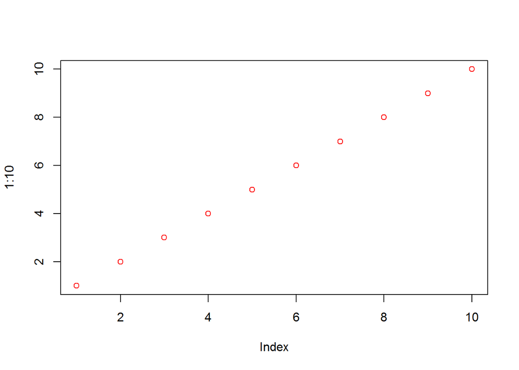

   ```r
   plot(1:10, col = "red")
   ```

   **A**: `col` is passed to several functions - `Axis()`, `box()`, `plot.window()` and `title()`. All these functions pass `col` as part of an `...` argument to `par()`, whose help page specifies `col` as a *specification for the default plotting color*.

## 1.5 Exiting a function

Most functions exit in one of two ways: either returning a value, indicating successful completion, or throwing an error, indicating failure. This section describes return values (implicit vs. explicit; visible vs. invisible), briefly discusses errors, and introduces exit handlers, which allow you to run code when a function exits, regardless of how it exits.

### 1.5.1 Implicit vs. explict returns

There are two ways that a function can return a value:

- Implicitly, where the last evaluated expression becomes the return value:

  ```r
  f <- function(x) {
      if (x < 10) {
          0
      } else {
          10
      }
  }
  f(5)
  ```

  ```
  ## [1] 0
  ```

  ```r
  f(15)
  ```

  ```
  ## [1] 10
  ```

- Explicitly, by calling `return()`:

  ```r
  f <- function(x) {
      if (x < 10) {
          return(0)
      } else {
          return(10)
      }
  }
  ```

### 1.5.2 Invisible values

Most functions return visibly: calling the function in an interactive context causes the result to be automatically printed.

```r
f1 <- function() 1
f1()
```

```
## [1] 1
```

However, it’s also possible to return an `invisible()` value, which is not automatically printed.

```r
f2 <- function() invisible(1)
f2()
```

You can verify that the value exists either by explicitly printing it or by wrapping in parentheses:

```r
print(f2())
```

```
## [1] 1
```

```r
(f2())
```

```
## [1] 1
```

Alternatively, use `withVisible()` to return the value and a visibility flag:

```r
str(withVisible(f2()))
```

```
## List of 2
##  $ value  : num 1
##  $ visible: logi FALSE
```

The most common function that returns invisibly is `<-`:

```r
a <- 2
(a <- 2)
```

```
## [1] 2
```

And this is what makes it possible to chain assignment:

```r
a <- b <- c <- d <- 2
```

In general, any function called primarily for its side effects (like `<-`, `print()`, or `plot()`) should return an invisible value (typically the value of the first argument).

### 1.5.3 Errors

If a function can not complete its assigned task, it should throw an error with `stop()`, which immediately terminates the execution of the function.

```r
f <- function() {
    stop("I'm an error")
    return(10)
}
f()
```

```
## Error in f(): I'm an error
```

### 1.5.4 Exit Handlers

Sometimes a function needs to make a temporary change to global state and you want to ensure those changes are restored when the function completes. It’s painful to make sure you cleanup before any explicit return, and what happens if there’s an error? Instead, you can set up an exiting handler that is called when the function terminates, regardless of whether it returns a value or throws an error.

```r
f <- function(x) {
    print("Hello")
    on.exit(print("Goodbye!"), add = TRUE)
    on.exit(print("Goodbye again!"), add = TRUE, after = FALSE)

    print(sys.on.exit())
    if (x) {
        return(10)
    } else {
        stop("Error")
    }
}

f(TRUE)
```

```
## [1] "Hello"
## {
##     print("Goodbye again!")
##     print("Goodbye!")
## }
## [1] "Goodbye again!"
## [1] "Goodbye!"
```

```
## [1] 10
```

```r
f(FALSE)
```

```
## [1] "Hello"
## {
##     print("Goodbye again!")
##     print("Goodbye!")
## }
```

```
## Error in f(FALSE): Error
```

```
## [1] "Goodbye again!"
## [1] "Goodbye!"
```

### 1.5.5 Exercises

1. What does `load()` return? Why don’t you normally see these values?  
   **A**: A character vector of the objects created from reloading datasets from a file. Returns invisibly.
2. What does `write.table()` return? What would be more useful?  
   **A**: `NULL`, invisibly. The object being written (first argument) which could then be piped to another function.
3. How does the `chdir` parameter of `source()` compare to `with_dir()`? Why might you prefer one approach to the other?

   ```r
   with_dir <- function(dir, code) {
       old <- setwd(dir)
       on.exit(setwd(old), add = TRUE)

       force(code)
   }
   ```

   **A**: The code for `source()` with regards to the `chdir` argument is essentially:

   ```r
   with_dir <- function(dir, code) {
       old <- getwd(dir)
       if (is.null(owd))
           stop("cannot 'chdir' as current directory is unknown")
       on.exit(setwd(old), add = TRUE)
       setwd(dir)

       force(code)
   }
   ```

   The latter code checks for a valid current directory before changing it. In the former code, if `setwd(dir)` returns `NULL` then the working directory will be set to `NULL` on exit of the function.
4. Write a function that opens a graphics device, runs the supplied code, and closes the graphics device (always, regardless of whether or not the plotting code worked).  
   **A**:

   ```r
   plot_pdf <- function(code) {
       pdf("test.pdf")
       on.exit(dev.off())
       code
   }
   ```

## 1.6 Function forms

Function calls come in four varieties:

- In **prefix** form, the function name comes before its arguments, like `foofy(a, b, c)`. These constitute of the majority of function calls in R.
- In **infix** form, the function name comes inbetween its arguments, like `x + y`. Infix forms are used for many mathematical operators, as well as user-defined functions that begin and end with %.
- A **replacement** function assigns into what looks like a prefix function, like `names(df) <- c("a", "b", "c")`.
- **Special forms** like `[[`, `if`, and `for`, don’t have a consistent structure and provide some of the most important syntax in R.

While four forms exist, you only need to use one, because any call can be written in prefix form.

### 1.6.1 Rewriting to prefix form

The following example shows three pairs of equivalent calls, rewriting an infix form, replacement form, and a special form into prefix form.

```
x + y
`+`(x, y)

names(df) <- c("x", "y", "z")
`names<-`(df, c("x", "y", "z"))

for(i in 1:3) print(i)
`for`(i, 1:3, print(i))
```

Overriding built-in functions is a bad idea!

```r
`(` <- function(e1) {
    e1 + 1
}
replicate(5, (1 + 2))
```

```
## [1] 4 4 4 4 4
```

```r
rm("(")
```

### 1.6.2 Prefix form

You can specify arguments in three ways:

- By position, like `help(mean)`.
- Using partial matching, like `help(to = mean)`.
- By name, like `help(topic = mean)`.

As illustrated by the following chunk, arguments are matched by exact name, then with unique prefixes, and finally by position.

```r
f <- function(abcdef, bcde1, bcde2) {
    list(a = abcdef, b1 = bcde1, b2 = bcde2)
}
str(f(1, 2, 3))
```

```
## List of 3
##  $ a : num 1
##  $ b1: num 2
##  $ b2: num 3
```

```r
str(f(2, 3, abcdef = 1))
```

```
## List of 3
##  $ a : num 1
##  $ b1: num 2
##  $ b2: num 3
```

```r
str(f(2, 3, a = 1))  # Can abbreviate long argument names:
```

```
## List of 3
##  $ a : num 1
##  $ b1: num 2
##  $ b2: num 3
```

```r
str(f(1, 3, b = 1))  # But this doesn't work because abbreviation is ambiguous
```

```
## Error in f(1, 3, b = 1): argument 3 matches multiple formal arguments
```

### 1.6.3 Infix functions

Infix functions are so called because the function name comes inbetween its arguments, and hence infix functions have two arguments. R comes with a number of built-in infix operators: `:`, `::`, `:::`, `$`, `@`, `^`, `*`, `/`, `+`, `-`, `>`, `>=`, `<`, `<=`, `==`, `!=`, `!`, `&`, `&&`, `|`, `||`, `~`, `<-`, and `<<-`. You can also create your own infix functions that start and end with `%`, and base R uses this to additionally define `%%`, `%*%`, `%/%`, `%in%`, `%o%`, and `%x%`.

Defining your own infix function is simple. You create a two argument function and bind it to a name that starts and ends with `%`:

```r
`%+%` <- function(a, b) paste0(a, b)
"new " %+% "string"
```

```
## [1] "new string"
```

R’s default precedence rules mean that infix operators are composed from left to right:

```r
`%-%` <- function(a, b) paste0("(", a, " %-% ", b, ")")
"a" %-% "b" %-% "c"
```

```
## [1] "((a %-% b) %-% c)"
```

There are two special infix functions that can be called with a single argument: `+` and `-`.

```r
-1
```

```
## [1] -1
```

```r
+10
```

```
## [1] 10
```

### 1.6.4 Replacement functions

Replacement functions act like they modify their arguments in place (they actually create a modified copy), and have the special name `xxx<-`. They typically have two arguments (`x` and `value`) and they must return the modified object. For example, the following function allows you to modify the second element of a vector:

```r
`second<-` <- function(x, value) {
    x[2] <- value
    x
}
```

Replacement functions are used by placing the function call on the LHS of `<-`:

```r
x <- 1:10
second(x) <- 5L
x
```

```
##  [1]  1  5  3  4  5  6  7  8  9 10
```

you want to supply additional arguments, they go inbetween x and value:

```r
`modify<-` <- function(x, position, value) {
    x[position] <- value
    x
}
x <- 1:10
modify(x, 1) <- 10
x
```

```
##  [1] 10  2  3  4  5  6  7  8  9 10
```

When you write modify(x, 1) <- 10, behind the scenes R turns it into:

```r
x <- 1:10
x <- `modify<-`(x, 1, 10)
x
```

```
##  [1] 10  2  3  4  5  6  7  8  9 10
```

### 1.6.5 Special forms

Finally, there are a bunch of language features that are usually written in special ways, but also have prefix forms. E.g. `x[i]` - `` `[`(x, i) ``

### 1.6.6 Exercises

1. Rewrite the following code snippets into prefix form

   ```r
   1 + 2 + 3
   1 + (2 + 3)
   if (length(x) <= 5) x[[5]] else x[[n]]
   ```

   **A**:

   ```
   `+`(`+`(1, 2), 3)
   `+`(1, `(`(`+`(2, 3)))
   'if'(`<=`(length(x), 5), `[[`(x, 5), `[[`(x, n))
   ```

2. Clarify the following list of odd function calls:

   ```r
   x <- sample(replace = TRUE, 20, x = c(1:10, NA))
   y <- runif(min = 0, max = 1, 20)
   cor(m = "k", y = y, u = "p", x = x)
   ```

   ```
   ## [1] -0.133004
   ```

   **A**:

   ```
   x <- sample(replace = TRUE, 20, x = c(1:10, NA))
   # first arg is x, hence by position, size = 20

   y <- runif(min = 0, max = 1, 20)
   # by position, argument n = 20

   cor(m = "k", y = y, u = "p", x = x)
   # m is partial for method - kendall is selected
   # u is partial for use - pairwise.complete.obs is selected
   ```

3. Explain why the following code fails:

   ```r
   modify(get("x"), 1) <- 10
   ```

   ```
   ## Error in modify(get("x"), 1) <- 10: target of assignment expands to non-language object
   ```

   ```r
   # same issue as
   1:2 <- 1
   ```

   ```
   ## Error in 1:2 <- 1: target of assignment expands to non-language object
   ```

   **A**: `get(x)` returns the **object** that has the name `x` bound to it. You cannot bind an object to an object, only to a name.
4. Create a replacement function that modifies a random location in a vector.  
   **A**:

   ```r
   `rp<-` <- function(x, value) {
       if (length(x) == 0 || is.null(x))
           stop("x is not valid")
       pos <- sample.int(length(x), 1)
       x[pos] <- value
       x
   }

   x <- 1:5
   rp(x) <- 6L
   x
   ```

   ```
   ## [1] 6 2 3 4 5
   ```

5. Write your own version of `+` that will paste its inputs together if they are character vectors but behaves as usual otherwise. In other words, make this code work:  
   **A**:

   ```r
   `+` <- function(x, y) {
       if (is.numeric(c(x, y))) {
           base::`+`(x, y)
       } else if (is.character(c(x, y))) {
           paste0(x, y)
       } else {
           NULL
       }
   }

   1 + 2
   ```

   ```
   ## [1] 3
   ```

   ```r
   1 + "2"
   ```

   ```
   ## [1] "12"
   ```

   ```r
   "a" + "b"
   ```

   ```
   ## [1] "ab"
   ```

   ```r
   rm(`+`)
   ```

6. Create a list of all the replacement functions found in the base package. Which ones are primitive functions? (Hint use `apropros()`)  
   **A**:

   ```r
   base_fn <- lsf.str(baseenv(), pattern = "*<-", all.names = TRUE)
   base_f <- mget(base_fn, inherits = TRUE)
   base_fp <- base_fn[map_lgl(base_f, ~is.primitive(.))]
   length(base_fp)
   ```

   ```
   ## [1] 17
   ```

   ```r
   base_fp
   ```

   ```
   ##  [1] "$<-"            "@<-"            "[[<-"           "[<-"
   ##  [5] "<-"             "<<-"            "attr<-"         "attributes<-"
   ##  [9] "class<-"        "dim<-"          "dimnames<-"     "environment<-"
   ## [13] "length<-"       "levels<-"       "names<-"        "oldClass<-"
   ## [17] "storage.mode<-"
   ```

7. What are valid names for user-created infix functions?  
   **A**: They can contain any sequence of characters except “%”. You will need to escape any special characters in the string used to define the function, but not when you call it:

   ```r
   `% %` <- function(a, b) paste(a, b)
   `%/\\%` <- function(a, b) paste(a, b)

   "a" % % "b"
   ```

   ```
   ## [1] "a b"
   ```

   ```r
   "a" %/\% "b"
   ```

   ```
   ## [1] "a b"
   ```

8. Create an infix `xor()` operator.  
   **A**:

   ```r
   `%xor%` <- function(x, y) {
       xor(x, y)
   }
   x <- c(T, T, F)
   y <- c(T, F, F)
   x %xor% y
   ```

   ```
   ## [1] FALSE  TRUE FALSE
   ```

9. Create infix versions of the set functions `intersect()`, `union()`, and `setdiff()`. You might call them `%n%`, `%u%`, and `%/%` to match conventions from mathematics. **A**:

   ```r
   `%n%` <- function(x, y) {
       intersect(x, y)
   }

   `%u%` <- function(x, y) {
       union(x, y)
   }

   `%/%` <- function(x, y) {
       setdiff(x, y)
   }

   x <- 1:3
   y <- 2:4

   x %n% y
   ```

   ```
   ## [1] 2 3
   ```

   ```r
   x %u% y
   ```

   ```
   ## [1] 1 2 3 4
   ```

   ```r
   x%/%y
   ```

   ```
   ## [1] 1
   ```